# Validity of a method for identifying disease subtypes that are etiologically heterogeneous

March 27, 2018

## Focus of epidemiologic research shifting from single disease by site to disease subtypes

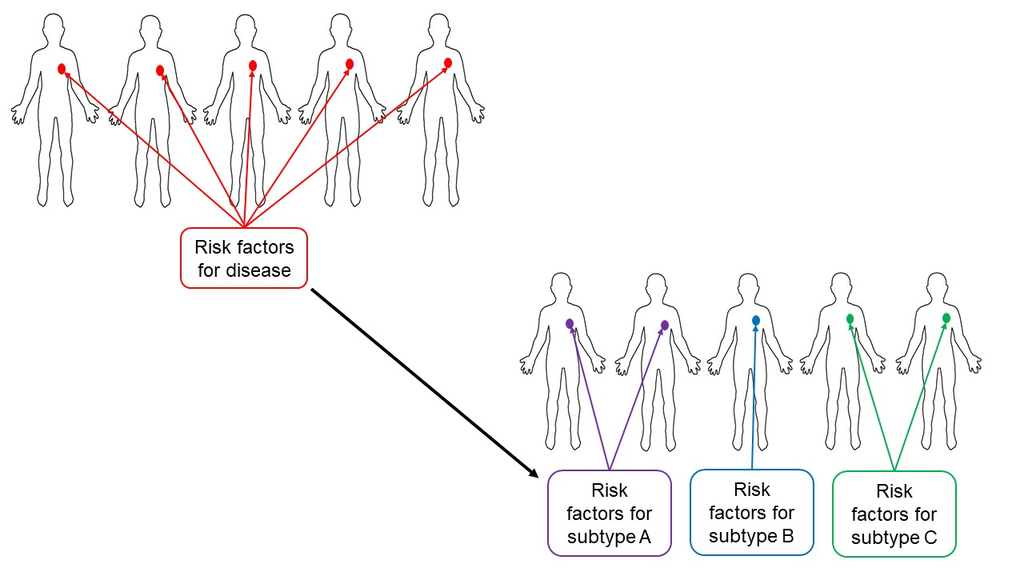

## Motivating data from the Cancer and Steroid Hormone (CASH) breast cancer case-control study

**Data**:

- 551 breast cancer cases
- 2990 population controls
- 12 risk factors for breast cancer
- 202 gene expression values (*cases only*)

**Goal**: To discover the most etiologically heterogeneous disease subtypes with respect to relevant risk factors, according to high dimensional tumor marker data.

## Proposed approach clusters marker data, optimizes etiologic heterogeneity

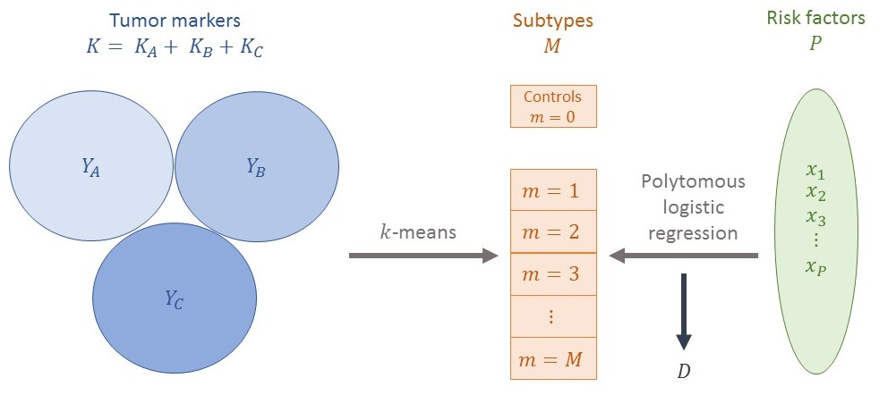

## Risk heterogeneity is measured using the coefficient of variation and risk covariance

The incremental explained variation is defined as the difference between the mean explainable risk variation and the overall risk variation.

For three subtypes \(A\), \(B\), and \(C\):

\[D = (\pi_A V^2_A + \pi_B V^2_B + \pi_C V^2_C) - V^2\] where \(\pi_j\) is the relative frequency and \(V_j^2\) is the coefficient of variation for subtype \(j\).

## But can this approach identify the subtypes that are truly the most etiologically heterogeneous?

Challenges:

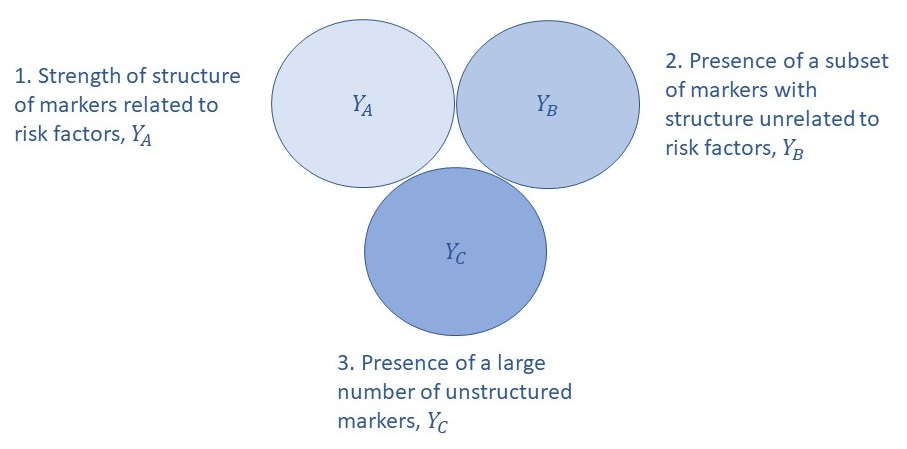

## Simplified simulation settings allow for investigation of the statistical properties

- Risk factor data \(X \sim N(\mu_m, I)\)
- Selected tumor markers are correlated with specific risk factors, inducing etiologic heterogeneity
  - Related markers: \(Y_A \sim N(\lambda_{Am}, I)\)
  - Unrelated markers: \(Y_B \sim N(\lambda_{Bj}, I)\)
  - Unstructured markers: \(Y_C \sim N(0, I)\)

## As strength in unrelated surpasses strength in related markers, misclassification increases

### Clustering \(K_A=15\) related and \(K_B=15\) unrelated

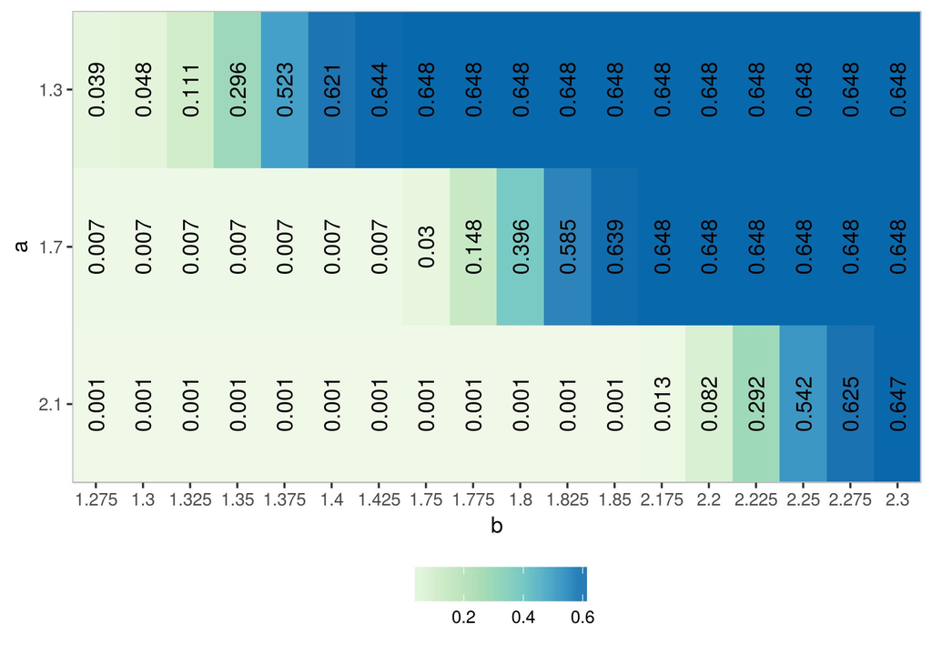

## Average maximum D decreases as strength in unrelated surpasses strength in related markers

### Clustering \(K_A=15\) related and \(K_B=15\) unrelated

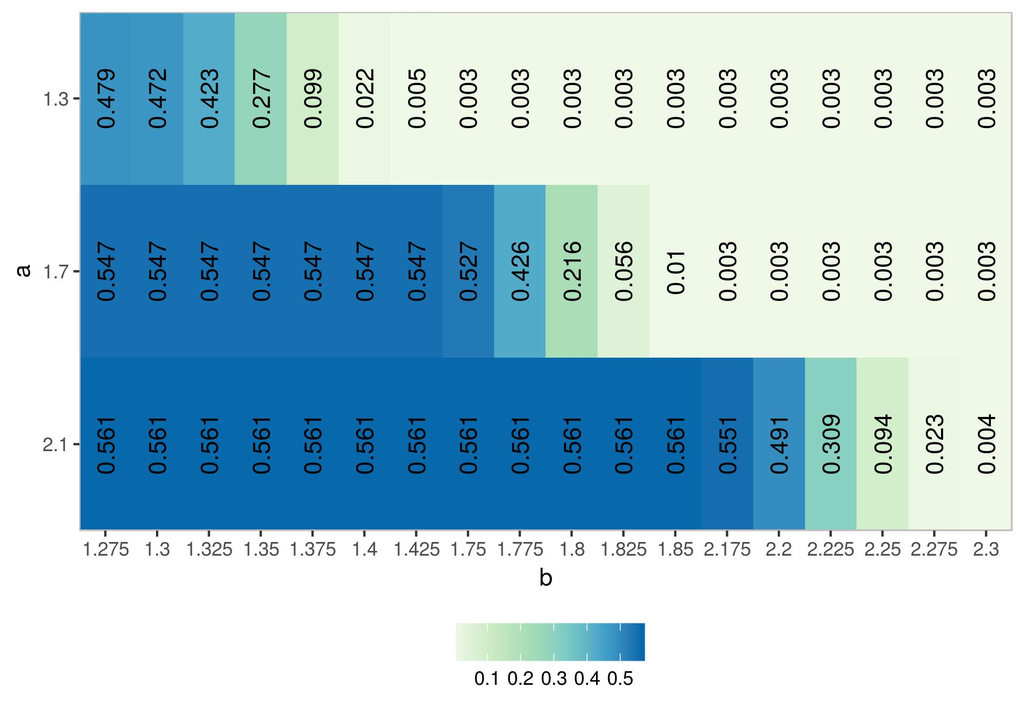

## Variable selection is based on individual \(D\) for each marker

1. \(K_A = 15\) related markers, \(K_B=15\) unrelated markers, \(K_C = 70\) noise markers
2. Individual \(D\) obtained for each marker by dichotomizing at median into two classes
3. Markers are ranked according to individual \(D\)
4. Set of included markers increased from \(5\) to \(100\), by \(5\)

### Dashed lines denote misclassification, solid lines denote \(D\)

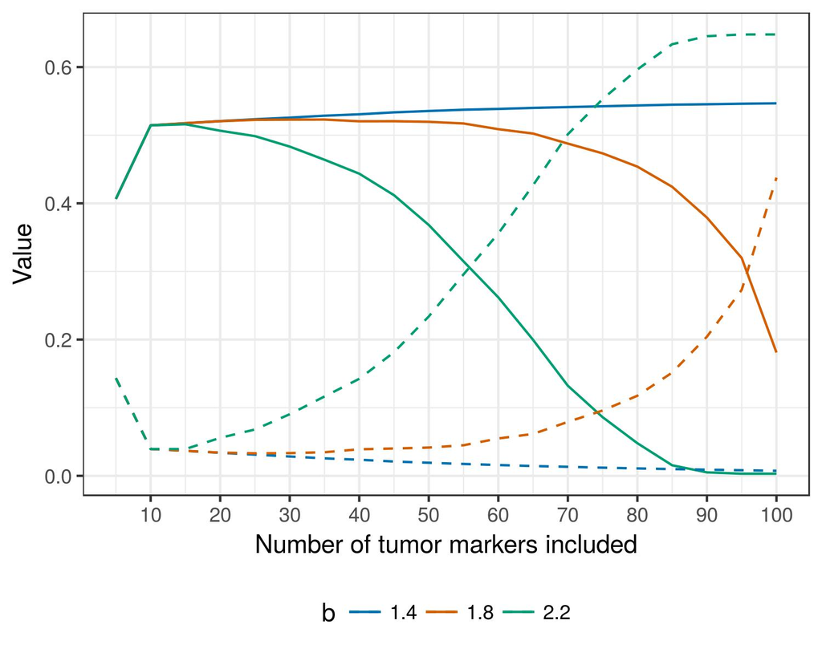

## More noisy markers than markers with structure unrelated to risk factors tend to get selected

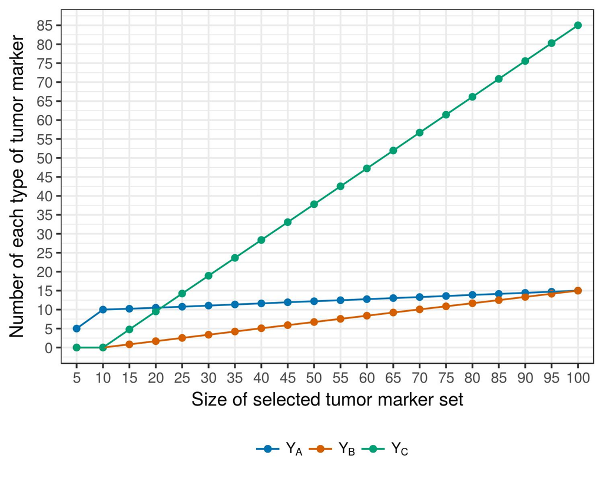

## Increasing noisy markers eventually overwhelms even strong structure

### Clustering 15 each related and unrelated, increasing \(K_C\)

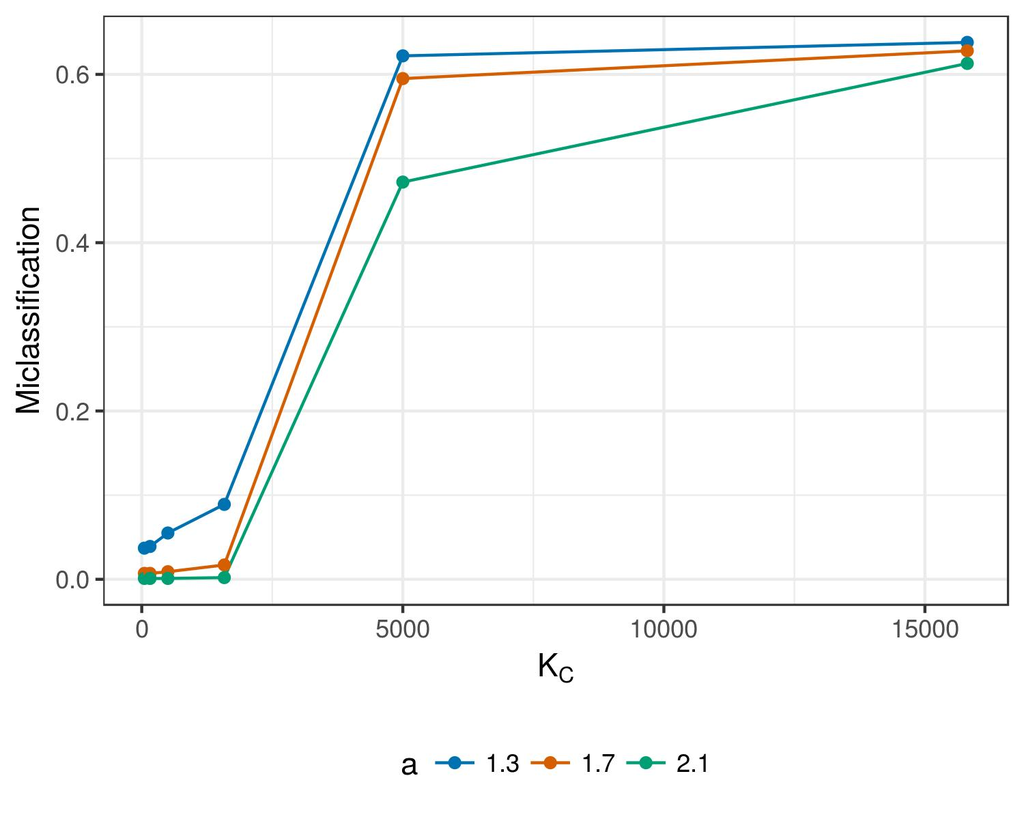

## Pre-clustering variable selection improves alignment with traditional classes in CASH/CARE

### 33 genes selected based on adjusted permutation p-values

| Full gene set | Her2-enriched | Luminal A | Luminal B | Triple neg |
| --- | --- | --- | --- | --- |
| 1 | 23 | 102 | 15 | 34 |
| 2 | 24 | 134 | 17 | 12 |
| 3 | 1 | 19 | 2 | 7 |
| 4 | 18 | 17 | 11 | 82 |

| Reduced gene set | Her2-enriched | Luminal A | Luminal B | Triple neg |
| --- | --- | --- | --- | --- |
| 1 | 46 | 60 | 27 | 27 |
| 2 | 8 | 118 | 12 | 13 |
| 3 | 1 | 89 | 6 | 4 |
| 4 | 11 | 5 | 0 | 91 |

## The method can find the true subtypes, and is enhanced by pre-clustering variable selection

`R` package `rickclustr` available at https://github.com/zabore/riskclustr

### Acknowledgements:

- Colin Begg, Memorial Sloan Kettering Cancer Center
- Shuang Wang, Columbia University
- Venkat Seshan, Memorial Sloan Kettering Cancer Center

### Contact:

- Email: zabore@mskcc.org
- Slides: https://github.com/zabore/slidedecks

[figure not shown]